# GeoLift_Walkthrough

# `GeoLift`: And end-to-end solution to Measure Lift at a Geo Level

## Installation

You can install `GeoLift` from GitHub using the `remotes` package.

```r
## Install remotes if noy already installed
install.packages("remotes", repos='http://cran.us.r-project.org')
## Install GeoLift from github
remotes::install_github("facebookincubator/GeoLift")
```

```r
library(augsynth)
library(gsynth)
library(GeoLift)
library(dplyr)
library(doParallel)
library(foreach)
library(MarketMatching)
```

## GeoLift Example

### Data

To show an end-to-end implementation of GeoLift we will use simulated data of 40 US cities across 90 days to first design a test, select test markets, run power calculations, and finally calculate the Lift caused by the campaign. As with every GeoLift test, we start analyzing pre-test historical information. We will use data included in the `GeoLift` package.

```r
data(GeoLift_PreTest)
```

The `GeoLift_PreTest` dataset contains three variables: location (city), date (in “yyyy-mm-dd” format), and Y (number of conversions in each day/location).

The first step to run a `GeoLift` test is to read the data into the proper format using the `GeoDataRead` function.

```r
GeoTestData_PreTest <- GeoDataRead(data = GeoLift_PreTest,
                                    date_id = "date",
                                    location_id = "location",
                                    Y_id = "Y",
                                    format = "yyyy-mm-dd")
head(GeoTestData_PreTest)
```

```
#>   location time    Y
#> 1  atlanta    1 3384
#> 2  atlanta    2 3904
#> 3  atlanta    3 5734
#> 4  atlanta    4 4311
#> 5  atlanta    5 3686
#> 6  atlanta    6 3374
```

This function analyzes the dataset, handles locations with missing data, and returns a data frame with time-stamps instead of dates. In this case, since we’re inputting daily data each time unit represents a day.

A good next step is to plot the panel data and observe it’s trend, contribution per location, and also to detect any data anomalies before moving on to the data analysis.

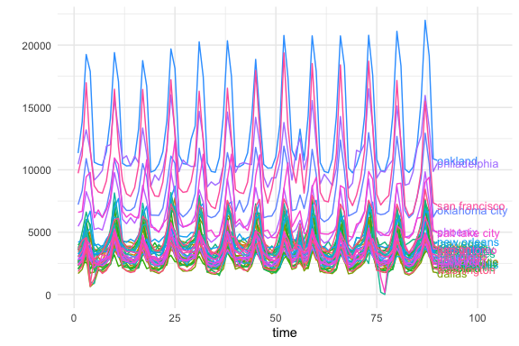

```r
GeoPlot(GeoTestData_PreTest,
        Y_id = "Y",
        time_id = "time",
        location_id = "location")
```

In this case we see a similar pattern that’s shared across all locations.

### Power Analysis

Running a power analysis is fundamental prior to executing a test. It is only through a thorough statistical analysis of our data that we can set-up a test for success. In general, through the power analysis we can find the optimal number of test locations, best test duration, select the ideal test and control markets, get a good idea of the budget needed to run a test, find which is the Minimum Detectable Effect to obtain significant results, and set proper expectations for the results.

#### How many test markets?

In general, there are two main types of users of `GeoLift`’s power calculations: * Those who through prior analysis already know which locations they want to test and simply want to validate their test design. * Users who do not have an initial design in mind and want to do a data-driven test set-up.

For those who fall under the second scenario, the first step is to get an idea of how many test locations we would generally need to obtain a well-powered test. This step allows us to better understand the data and narrow down the number of test configurations. This analysis can be achieved using the `NumberLocations` function of `GeoLift` which works by simulating a large amount of tests and assess their results and fit statistics.

The parameters used in the `NumberLocations` function inform the names of the time, location, and units variables (time_id, location_id, and time_id respectively) in the input data. We also specify the length of the test we have on mind with the treatment_periods parameter (if not sure, you can enter a list of test lengths too), the number of simulations we want to run, control the output through the optional plotting and progress bar parameters, set the desired significance and power level, and also decide whether to include unit fixed-effects to the model. There are several additional parameters that can be used to further customize the simulations and outputs which can be accessed in the package’s documentation.

```
#> Attempting to load the environment 'package:tidyr'
#> [1] "Average Power By Number of Locations"
#> # A tibble: 12 x 3
#>        n mean_pow mean_L2ScaledImbalance
#>    <dbl>    <dbl>                  <dbl>
#>  1     0    0                      1
#>  2     1    0.88                   0.436
#>  3     2    0.872                  0.413
#>  4     4    0.868                  0.382
#>  5     7    0.84                   0.364
#>  6     8    0.866                  0.363
#>  7    10    0.862                  0.354
#>  8    13    0.856                  0.358
#>  9    15    0.838                  0.375
#> 10    16    0.832                  0.373
#> 11    18    0.802                  0.377
#> 12    20    0.804                  0.389
```

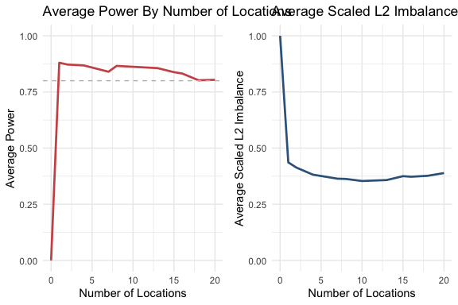

```r
resultsNum <- NumberLocations(data = GeoTestData_PreTest,
                                Y_id = "Y",
                                location_id = "location",
                                time_id = "time",
                                n_sim = 500,
                                treatment_periods = 15,
                                plot = TRUE,
                                power = 0.8,
                                alpha = 0.1,
                                fixed_effects = TRUE,
                                ProgressBar = TRUE)
```

The results show that we can obtain well-powered test even from just a few locations. Moreover, the output shows the Scaled L2 Imbalance metric, which is a metric between 0 and 1 that represents how well the model is predicting the pre-treatment observed values through the Synthetic Control. Scaled L2 Imbalance values of 0 show a perfect match of pre-treatment values and values of 1 show a very inaccurate prediction. In this case, we observe that this metric is relatively stable once we have a couple or more test locations. These results provide a good starting point as we now know that we can get a well-powered test even if we just have a few test locations. In any case, it is important to mention that `NumberLocations` is just menat to guide our analysis as power can drastically change between different market selections even if we keep the same number of test markets.

#### Market Selection

Once that we have a better idea of how many markets are needed for a well.powered test, we can proceed to the Market Selection. In this step we use simulations to find which are the best combinations of test and control locations for a predetermined number of test markets. This process can be accomplished using the `GeoLiftPower.search` function which will simulate a large amount of tests using rolling windows of dates to find which combinations of test and control locations can consistently provide stable and well-powered tests.

Similar to the previous function, we communicate to `GeoLiftPower.search` the layout of our object through the time_id, location_id, and Y_id parameters. In addition, we set a test length (or lengths if unsure) using the treatment_periods parameter and significance level through alpha. Moreover, the horizon parameter allows us to focus more on more recent time-stamps. This is especially useful if we see that older time-periods have significantly different dynamics to the more recent (ones where the test would take place). In this case, setting horizon = 50 is telling `GeoLiftPower.search` that we should focus on time periods [50,90]. In addition, the N parameter specifies the total number of locations that can be part of the test. Following the results found by `NumberLocations` we focus on test designs that have between 2 and 4 cities in the test group. Finally, some of the outputs of the function can be controlled through parameters such as top_results which will determine how many of the top locations will be printed.

```r
resultsSearch <- GeoLiftPower.search(data = GeoTestData_PreTest,
                                     treatment_periods = c(15),
                                     N = c(2,3,4),
                                     horizon = 50,
                                     Y_id = "Y",
                                     location_id = "location",
                                     time_id = "time",
                                     top_results = 20,
                                     alpha = 0.1,
                                     type = "pValue",
                                     fixed_effects = TRUE,
                                     ProgressBar = TRUE)
```

```
#> [1] "Best 20 test markets:"
#> # A tibble: 20 x 1
#>    location
#>    <chr>
#>  1 chicago, portland
#>  2 chicago, cincinnati
#>  3 chicago, cincinnati, houston, portland
#>  4 chicago, houston, portland
#>  5 columbus, jacksonville, minneapolis
#>  6 columbus, jacksonville, milwaukee, minneapolis
#>  7 jacksonville, minneapolis
#>  8 atlanta, chicago, cincinnati, san diego
#>  9 jacksonville, kansas city, milwaukee, new orleans
#> 10 jacksonville, kansas city, milwaukee, oakland
#> 11 kansas city, milwaukee, oakland
#> 12 columbus, minneapolis, new york
#> 13 detroit, jacksonville, new orleans
#> 14 atlanta, chicago, cincinnati
#> 15 nashville, san diego
#> 16 cleveland, denver, washington
#> 17 dallas, washington
#> 18 cleveland, dallas, denver, washington
#> 19 cleveland, denver
#> 20 atlanta, chicago, reno
```

The results show the best combination of test markets, the average power that the combination was able to provide, its the average Scaled L2 Imbalance across all simulations, the proportion of total conversions that the test markets represent, and it’s overall rank determined by power and imbalance. In this case, we see that a test that uses the combination of Chicago and Portland as test locations appears as the top-ranked choice.

Inspecting the object created by `GeoLiftPower.search` shows us a more detailed list of results.

```r
head(resultsSearch,50)
```

```
#>                                                location mean_pow
#> 1                                     chicago, portland        1
#> 2                                   chicago, cincinnati        1
#> 3                chicago, cincinnati, houston, portland        1
#> 4                            chicago, houston, portland        1
#> 5                   columbus, jacksonville, minneapolis        1
#> 6        columbus, jacksonville, milwaukee, minneapolis        1
#> 7                             jacksonville, minneapolis        1
#> 8               atlanta, chicago, cincinnati, san diego        1
#> 9     jacksonville, kansas city, milwaukee, new orleans        1
#> 10        jacksonville, kansas city, milwaukee, oakland        1
#> 11                      kansas city, milwaukee, oakland        1
#> 12                      columbus, minneapolis, new york        1
#> 13                   detroit, jacksonville, new orleans        1
#> 14                         atlanta, chicago, cincinnati        1
```

[output cut: 87 more lines]

One key part of `GeoLiftPower.search` is that it use the similarities between the market’s time series to determine hot to best combine them into the test and control groups. This is important as Synthetic Control Methods rely on the availability of similar markets to the test in order to create the counterfactual. For this reason, the `MarketSelection` function is a core part of `GeoLiftPower.search`. To obtain a better understanding of the similarity structure between our cities you could run `MarketSelection`.

```r
MarketSelection(GeoTestData_PreTest, location_id = "location", time_id = "time", Y_id = "Y")[1:5,1:5]
```

```
#>      [,1]          [,2]           [,3]            [,4]          [,5]
#> [1,] "atlanta"     "chicago"      "las vegas"     "cleveland"   "reno"
#> [2,] "austin"      "oakland"      "oklahoma city" "kansas city" "saint paul"
#> [3,] "baltimore"   "philadelphia" "reno"          "chicago"     "houston"
#> [4,] "baton rouge" "portland"     "cincinnati"    "san diego"   "chicago"
#> [5,] "boston"      "new orleans"  "jacksonville"  "milwaukee"   "detroit"
```

The results show a matrix of similarities, where columns 2 onward represents an ordered list of the most similar location to the one showed in the first column. For instance, these results show that the most similar city to Atlanta is Chicago followed by Las Vegas and Cleveland.

#### What about the Minum Detectable Effect?

Even though `GeoLiftPower.search` showed us which combination of test and control markets were able to consistently obtain well-powered results in a Synthetic Control test, it doesn’t tell us what is the Lift we would need to obtain that powerful test. That’s why we recommend to supplement the results of `GeoLiftPower.search` with the simulations run by the function `GeoLiftPowerFinder`. More specifically, while the former analyzes the stability of the time-series and ability of a SCM to replicate the results, the latter explores the Minimum Detectable Effect that a combination of test and control locations would provide.

The parameters needed by `resultsFind` are very similar to the ones used by `GeoLiftPower.search` with the difference that this function doesn’t use a horizon as it will focus on the most recent available data to run a test as it is the one that would be closest to the market dynamics that a test would experience. Also, a sequence of Effect Sizes or Lifts are needed by this function as part of the effect_size parameter. Each element on this sequence will be assessed to find the test’s Minimum Detectable Effect. In this case, we entered two different test lengths: 10 and 15 days as part of the treatment_periods parameter. Setting the plot_best parameter to TRUE will output the plot of the top 4 test markets to perform a deeper dive.

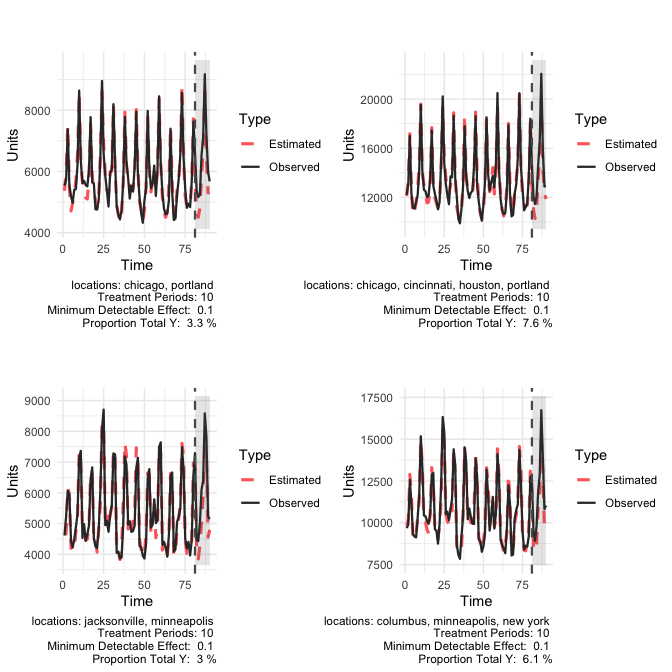

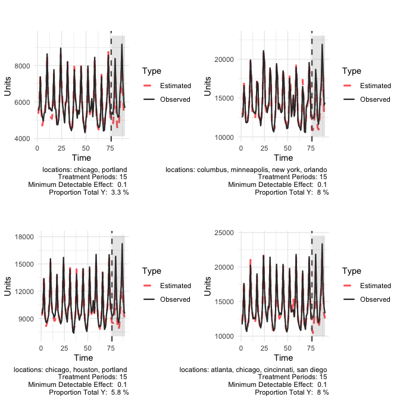

```r
resultsFind <- GeoLiftPowerFinder(data = GeoTestData_PreTest,
                                  treatment_periods = c(10,15),
                                  N = c(2,3,4),
                                  Y_id = "Y",
                                  location_id = "location",
                                  time_id = "time",
                                  effect_size = seq(0, 0.5, 0.05),
                                  top_results = 5,
                                  alpha = 0.1,
                                  fixed_effects = TRUE,
                                  ProgressBar = TRUE,
                                  plot_best = TRUE)
```

```r
head(resultsFind,10)
```

```
#>                                    location pvalue duration MinDetectableEffect
#> 1                         chicago, portland      0       10                 0.1
#> 2                         chicago, portland      0       15                 0.1
#> 3    chicago, cincinnati, houston, portland      0       10                 0.1
#> 4  columbus, minneapolis, new york, orlando      0       15                 0.1
#> 5                 jacksonville, minneapolis      0       10                 0.1
#> 6                chicago, houston, portland      0       15                 0.1
#> 7   atlanta, chicago, cincinnati, san diego      0       15                 0.1
#> 8           columbus, minneapolis, new york      0       10                 0.1
#> 9                            dallas, denver      0       15                 0.1
#> 10     jacksonville, milwaukee, new orleans      0       10                 0.1
#>    ScaledL2Imbalance ProportionTotal_Y rank
#> 1          0.1682310        0.03306537    1
#> 2          0.1738778        0.03306537    2
#> 3          0.1966996        0.07576405    3
#> 4          0.2245568        0.08010168    4
#> 5          0.2278603        0.03032910    5
#> 6          0.2336638        0.05797087    6
#> 7          0.2421710        0.07972448    7
#> 8          0.2636719        0.06085010    8
#> 9          0.2639271        0.03307564    9
#> 10         0.2671716        0.06786505   10
```

The results echo the findings of `GeoLiftPower.search` and show that the combination of Chicago and Portland as test locations is optimal in terms of stability and a Minimum Detectable Effect that is both small and which has high certainty. Moreover, the Scaled L2 Imbalance results show a good fit of the Synthetic Control on pre-treatment periods.

#### Finding the Duration and Budget

So far our Market Selection based on Power Analyses provided us with a promising combination of test and control locations. Specifically, we would focus our treatment on Chicago and Portland while putting the rest of the locations in the holdout group. However, we still haven’t found the ideal test duration and estimated budget to necessary to run this test. To do so, we need to perform a more thorough Power Analysis focused on our chosen test configuration. The `GeoLiftPower` function takes a set of test cities defined in the locations parameter, together with a horizon, a sequence of lifts or effect sizes to be analyzed, and a Cost Per Incremental Conversion (CPIC). This CPIC will allow us to estimate the budget needed to achieve the required lift for a well-powered test. Moreover, providing a list of different length durations in the treatment_periods parameter lets us see what the ideal test duration should be for this particular set of test locations.

```
#>    duration lift     power
#> 1        10 0.00 0.0000000
#> 2        10 0.01 0.0000000
#> 3        10 0.02 0.0000000
#> 4        10 0.03 0.0000000
#> 5        10 0.04 0.0312500
#> 6        10 0.05 0.1562500
#> 7        10 0.06 0.4375000
#> 8        10 0.07 0.5625000
#> 9        10 0.08 0.7812500
#> 10       10 0.09 0.9062500
#> 11       10 0.10 0.9687500
#> 12       10 0.11 0.9687500
#> 13       10 0.12 1.0000000
#> 14       10 0.13 1.0000000
```

[output cut: 39 more lines]

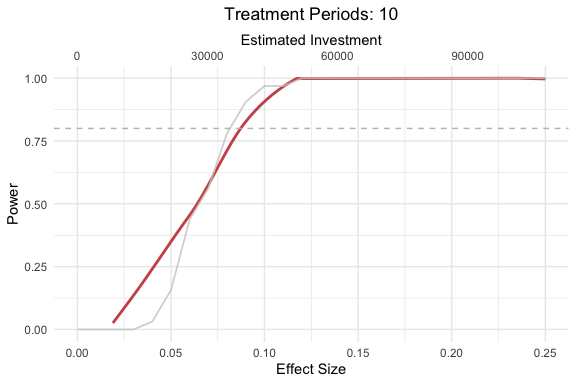

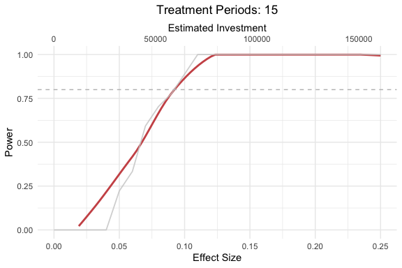

```r
locs <- c("chicago", "portland")

resultsPow <- GeoLiftPower(GeoTestData_PreTest,
                           locations = locs,
                           effect_size = seq(0,0.25,0.01),
                           treatment_periods = c(10,15),
                           horizon = 50,
                           Y_id = "Y",
                           location_id = "location",
                           time_id = "time",
                           cpic = 7.50)

plot(resultsPow, actual_values = TRUE)
```

### Analyzing the Test Results

Based on the results of the Power Calculations, a test is set-up in which a 15-day marketing campaign will be executed in the cities of Chicago and Portland while the rest of the locations will be put on holdout. Following the completion from this marketing campaign, we receive sales data that reflects these results. This new data-set contains the same format and information as the pre-test one but crucially includes results for the duration of the campaign. Depending on the vertical and product, adding a post-campaign cooldown period might be useful.

#### Test Data

Data for the campaign results can be accessed at `GeoLift_Test`.

```r
data(GeoLift_Test)
```

Similarly to the process executed at the beginning of the Power Analysis phase, we read the data into GeoLift’s format using the `GeoDataRead` function.

```r
GeoTestData_Test <- GeoDataRead(data = GeoLift_Test,
                                    date_id = "date",
                                    location_id = "location",
                                    Y_id = "Y",
                                    format = "yyyy-mm-dd")
head(GeoTestData_Test)
```

```
#>   location time    Y
#> 1  atlanta    1 3384
#> 2  atlanta    2 3904
#> 3  atlanta    3 5734
#> 4  atlanta    4 4311
#> 5  atlanta    5 3686
#> 6  atlanta    6 3374
```

The results can also be plotted using the `GeoPlot` function. However, for post-campaign data we can include the time-stamp at which the campaign started through the treatment_start parameter to clearly separate the two periods. Plotting the time-series is always useful to detect any anomalies with the data and to start noticing patterns with the test.

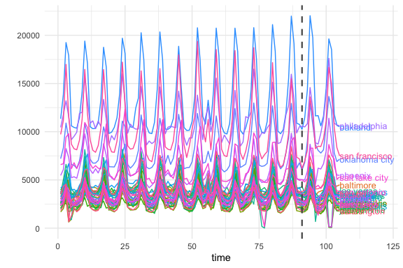

```r
GeoPlot(GeoTestData_Test,
        Y_id = "Y",
        time_id = "time",
        location_id = "location",
        treatment_start = 91)
```

#### GeoLift Inference

The next step in the process is to calculate the actual Lift caused by the marketing campaigns on our test locations. To do so we make use of the `GeoLift` function, which will take as input the GeoLift dataframe as well as information about the test such as which were the cities in the treatment group, when the test started, and when it ended through the locations, treatment_start_time, and treatment_end_time parameters respectively.

```r
GeoTest <- GeoLift(Y_id = "Y",
                    data = GeoTestData_Test,
                    locations = locs,
                    treatment_start_time = 91,
                    treatment_end_time = 105)
```

```
#>
#> GeoLift Output
#>
#> Test results for 15 treatment periods, from time-stamp 91 to 105 for test markets:
#> 1 CHICAGO
#> 2 PORTLAND
#> ##################################
#> #####     Test Statistics    #####
#> ##################################
#>
#> Percent Lift: 5.4%
#>
#> Incremental Y: 4667
#>
#> Average Estimated Treatment Effect (ATT): 155.556
#>
#> The results are significant at a 95% level.
#>
#> There is a 0.7% chance of observing an effect this large or larger assuming treatment effect is zero.
```

```r
summary(GeoTest)
```

```
#>
#> GeoLift Results Summary
#> ##################################
#> #####     Test Statistics    #####
#> ##################################
#>
#> * Average ATT: 155.556
#> * Percent Lift: 5.4%
#> * Incremental Y: 4667
#> * P-value: 0.01
#>
#> ##################################
#> #####   Balance Statistics   #####
#> ##################################
#>
#> * L2 Imbalance: 909.489
#> * Scaled L2 Imbalance: 0.1636
#> * Percent improvement from naive model: 83.64%
#> * Average Estimated Bias: NA
#>
#> ##################################
#> #####     Model Weights      #####
#> ##################################
#>
#> * Prognostic Function: NONE
#>
#> * Model Weights:
#>  * austin: 0.0465
#>  * baton rouge: 0.1335
#>  * cincinnati: 0.2272
#>  * dallas: 0.0739
#>  * honolulu: 0.0673
#>  * houston: 0.0046
#>  * miami: 0.2028
#>  * minneapolis: 0.09
#>  * nashville: 0.0685
#>  * new york: 0.0046
#>  * reno: 0.0306
#>  * san antonio: 0.0054
#>  * san diego: 0.0451
```

The summary show additional test statistics such as the p-value which was equal to 0.01 confirming the highly statistical significance of these results. Moreover, the summary function provides Balance Statistics which display data about our model’s fit. The main metric of model fit used in GeoLift is the L2 Imbalance which represents how far our synthetic control was from the actual observed values in the pre-treatment period. That is, how similar the synthetic Chicago + Portland unit we crated is from the observed values of these cities in the period before the intervention. A small L2 Imbalance score means that our model did a great job replicating our test locations while a large one would indicate a poor fit. However, the L2 Imabalnce metric is scale-dependent, meaning that it can’t be compared between models with different KPIs or number of testing periods. For instance, the L2 Imbalance of a model run on units sold will be significantly larger than a model ran for tons of product sold even if they represent the same basic underlying metric.

Therefore, given that it’s hard to tell simply by looking at the value of the L2 Imbalance metric whether the model had a good or poor fit, we also included the Scaled L2 Imbalance stat which is easier to interpret as it’s bounded in the range between 0 and 1. A value close to zero represents a good model fit while values nearing 1 indicate a poor performance by the Synthetic Control Model. This scaling is accomplished by comparing the Scaled L2 Imbalance of our Synthetic Control Method with the Scaled L2 Imbalance obtained by a baseline/naive model (instead of carefully calculating which is the optimal weighting scheme for the Synthetic Control, we assign equal weights to each unit in the donor pool). The latter provides an upper bound of L2 Imbalance, therefore, the Scaled L2 Imbalance shows us how much better our GeoLift model is from the baseline.

In fact, another way to look at the Scaled L2 Imbalance is the percent improvement from a naive model which can be obtained by subtracting our model’s Scaled L2 Imbalance from 100%. In this case, an improvement close to 100% (which corresponds to a Scaled L2 Imbalance close to zero) represents a good model fit. Finally, we also include the weights that generate our Synthetic Control. In this test we note that the locations that contribute the most to our GeoLift model are Cincinnati, Miami, and Baton Rouge.

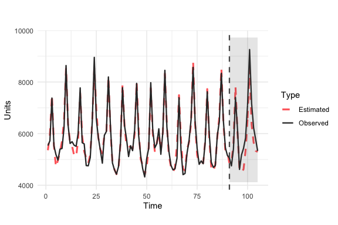

```r
plot(GeoTest, type = "Lift")
```

Plotting the results is a great way to assess the model’s fit and how effective the campaign was. Taking a close look at the pre-treatment period (white background) provides insight into how well our Synthetic Control Model fitted our data. In this specific example, we see that the observed values of the Chicago + Portland test represented in the solid black line were closely replicated by our model shown as the dashed red line. Furthermore, looking at the test period, we can notice the campaign’s incrementality shown as the difference between the sales observed in the test markets and our counterfactual synthetic location. This marked difference between an almost-exact match in pre-treatment periods and gap in test time-stamps provides strong evidence of a successful campaign.

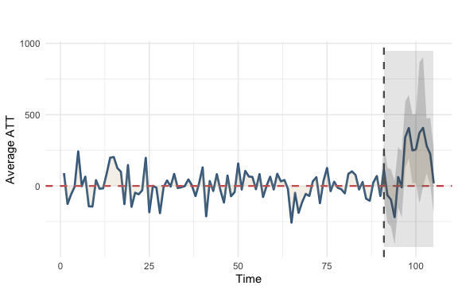

```r
plot(GeoTest, type = "ATT")
```

Looking at the Average Estimated Treatment Effect’s plot can also be extremely useful. The ATT metric shows us the magnitude of the Average Treatment Effect on a daily basis in contrast with the previous (Lift) plot which focused on aggregated effects. Moreover, this is a great example of a good GeoLift model as it has very small ATT values in the pre-treatment period and large ones when the treatment is administered to our test locations. Moreover, point-wise confidence intervals are included in this chart which help us measure how meaningful each day Lift has been.

#### Improving The Model

While the results obtained from the test are robust and highly significant, a useful feature of GeoLift is its ability to improve the model fit even further and reduce bias through augmentation by a prognostic function. There are several options for augmentation of the standard GeoLift model such as regularization (specifically Ridge) and a application of Generalized Synthetic Control Model (GSC). While each of these approaches provide it’s own set of advantages, for instance Ridge regularization usually performs well when the number of units and time-periods isn’t large while GSC helps improve fit for situations with many pre-treatment periods, GeoLift offers the option to let the model decide which is the best approach by setting the model parameter to “best”.

```r
GeoTestBest <- GeoLift(Y_id = "Y",
                        data = GeoTestData_Test,
                        locations = locs,
                        treatment_start_time = 91,
                        treatment_end_time = 105,
                        model = "best")
```

```
#>
#> GeoLift Output
#>
#> Test results for 15 treatment periods, from time-stamp 91 to 105 for test markets:
#> 1 CHICAGO
#> 2 PORTLAND
#> ##################################
#> #####     Test Statistics    #####
#> ##################################
#>
#> Percent Lift: 5.5%
#>
#> Incremental Y: 4704
#>
#> Average Estimated Treatment Effect (ATT): 156.805
#>
#> The results are significant at a 95% level.
#>
#> There is a 1.2% chance of observing an effect this large or larger assuming treatment effect is zero.
```

```r
summary(GeoTestBest)
```

```
#>
#> GeoLift Results Summary
#> ##################################
#> #####     Test Statistics    #####
#> ##################################
#>
#> * Average ATT: 156.805
#> * Percent Lift: 5.5%
#> * Incremental Y: 4704
#> * P-value: 0.01
#>
#> ##################################
#> #####   Balance Statistics   #####
#> ##################################
#>
#> * L2 Imbalance: 903.525
#> * Scaled L2 Imbalance: 0.1626
#> * Percent improvement from naive model: 83.74%
#> * Average Estimated Bias: -1.249
#>
#> ##################################
#> #####     Model Weights      #####
#> ##################################
#>
#> * Prognostic Function: RIDGE
#>
#> * Model Weights:
#>  * atlanta: 3e-04
#>  * austin: 0.0467
#>  * baltimore: 1e-04
#>  * baton rouge: 0.1337
#>  * boston: -4e-04
#>  * cincinnati: 0.2273
#>  * columbus: 1e-04
#>  * dallas: 0.0741
#>  * denver: 1e-04
#>  * detroit: 1e-04
#>  * honolulu: 0.0674
#>  * houston: 0.0048
#>  * indianapolis: 1e-04
#>  * jacksonville: -1e-04
#>  * kansas city: -1e-04
#>  * los angeles: 2e-04
#>  * memphis: -2e-04
#>  * miami: 0.2029
#>  * milwaukee: -2e-04
#>  * minneapolis: 0.0901
#>  * nashville: 0.0687
#>  * new orleans: -2e-04
#>  * new york: 0.0048
#>  * oakland: -0.001
#>  * oklahoma city: -7e-04
#>  * orlando: 1e-04
#>  * philadelphia: -4e-04
#>  * reno: 0.0308
#>  * saint paul: 2e-04
#>  * salt lake city: -3e-04
#>  * san antonio: 0.0056
#>  * san diego: 0.0452
#>  * san francisco: 1e-04
#>  * tucson: -1e-04
```

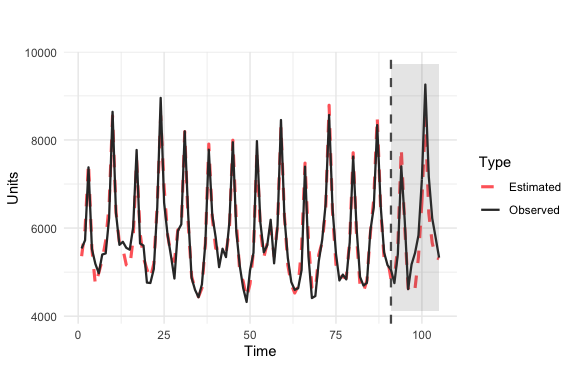

```r
plot(GeoTestBest, type = "Lift")
```

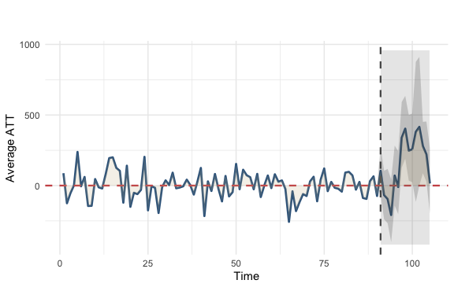

```r
plot(GeoTestBest, type = "ATT")
```

The new results augment the GeoLift model with a Ridge prognostic function which improves the model fit as seen in the new L2 Imbalance metrics. This additional robustness is translated in a small increase in the Percent Lift. Furthermore, by augmenting the model with a prognostic function, we have an estimate of the estimated bias.